# xwMOOC 자연어 처리 - 텍스트

LangCon - 자연어 처리의 화장을 하지 않은 얼굴(민낯): 튜토리얼

xwMOOC

Tidyverse Korea

2019-02-14

# 1 튜토리얼 소개

[LangCon2019 : 자연어처리하기 좋은 날입니다!](https://songys.github.io/2019LangCon/)에서 “유튜브 댓글 텍스트 분석”을 주제로 튜토리얼을 시작합니다.

- [R 언어 NLP 생태계](http://www.bnosac.be/index.php/blog): [NLP 생태계 이미지](http://www.bnosac.be/images/bnosac/blog/NLP-R-ecosystem.png)
- R 개발자가 알아야 되는 보안
- 유튜브 API
- 유튜브 댓글: [자료구조](https://statkclee.github.io/parallel-r/r-parallel-fp-ds.html)
- SNS 트래픽 분석: [재보선 2019 선거 - “유튜브”](https://statkclee.github.io/text/nlp-youtube-comment.html)
- 자연어처리 (파이썬)
  1. 자연어 처리 입문 - 텍스트 → 단어주머니(Bag of Words)
- 자연어처리 (영문)
  - 텍스트 마이닝
    1. 케인즈 vs 하이에크
    2. 케인즈 vs 하이에크 - 감성, 핵심어, 연관단어
    3. 케인즈 vs 하이에크 - 토픽모형
    4. 케인즈 vs 하이에크 - `spacyr`
  - 모형
    - [SMS 스팸분류 - Random Forest](https://statkclee.github.io/text/nlp-spam-machine-learning.html)
    - [캐글 - 전자상거래 옷 리뷰](https://statkclee.github.io/text/text-kaggle-ecommerce-review.html)
- 자연어처리 - 한국어
  - [네이버 뉴스](https://statkclee.github.io/text/nlp-naver-news.html)
  - 알릴레요 vs. 홍카콜라 - 댓글 분류

[figure not shown]

# 2 자연어처리 범위

## 2.1 NLP 생태계

[figure not shown]

## 2.2 텍스트 마이닝

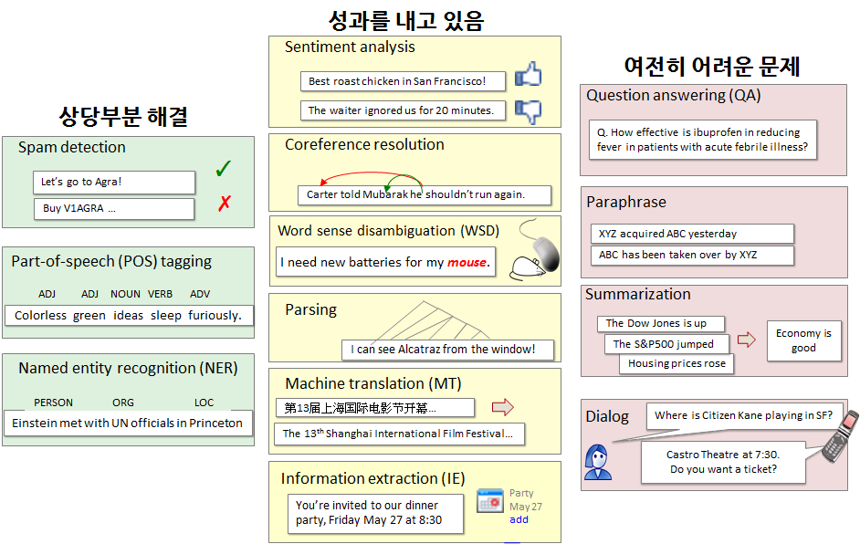

# 3 클라우드 시대 보안키 [^1]

1. R이 설치된 디렉토리를 탐색기를 통해 찾아간다.
   - `C:\Program Files\R\R-3.5.1\etc`
2. `Rprofile.site` 파일을 찾아 환경설정을 한다.

```r
# Rprofile.site 파일
AWS_ACCESS_KEY_ID <-  "Axxx"
AWS_SECRET_ACCESS_KEY <- "pxxx"
```

# 4 유튜브 API [^2]

[xwMOOC, “R 구글 애널리틱스(GA)”](https://statkclee.github.io/deep-learning/r-ga.html) 참조하여 유튜브 API 데이터를 가져올 수 있도록 한다.

# 5 SNS 트래픽 분석 [^3]

[xwMOOC, “유트브 댓글”](https://statkclee.github.io/text/nlp-youtube-comment.html)

# 6 자연어처리 (파이썬)

자연어 처리 입문 - 텍스트 → 단어주머니(Bag of Words)

# 7 자연어처리 (영문)

- 텍스트 마이닝
  1. 케인즈 vs 하이에크
  2. 케인즈 vs 하이에크 - 감성, 핵심어, 연관단어
  3. 케인즈 vs 하이에크 - 토픽모형
  4. 케인즈 vs 하이에크 - `spacyr`

# 8 자연어처리 (모형) - 분류